# Final Exam

Eric Reyes

Fall 2016

## Instructions

The final exam consists of 10 programming exercises, each representing one module from the course. In order to receive a base-level pass, you must successfully complete 5 of the 10 exercises; in order to receive an advanced-level pass, you must successfully complete 8 of the 10 exercises.

- You have 4 hours to complete the exam.
- You should submit both your `R` code as well as any additional output requested from the problem.
- You may use any previously constructed written resources during the exam. This includes notes, texts, and online resources. However, you are prohibited from speaking to anyone other than the instructor regarding the exam (this includes other students, faculty, and all communication via email or message boards). To be specific, if you find something useful on a previously existing thread of a message board, you may use it. However, you may not post a question on a message board in order to receive help.

Your final file(s) should be submitted via the dropbox on the course page (under the Capstone Project section of the site). If you have any questions during the exam, you should not hesitate to ask the instructor.

By taking this exam, you assert that you neither gave nor received unauthorized aid during the course of the exam.

## Background

Baseball is considered “America’s Pasttime” (however, the instructor does not share this perspective and personally finds the game boring). Like many other sporting events, the game generates a lot of data at both the player and team levels. Some rare events in baseball include pitching a no-hitter (a game without a hit) and hitting a grand slam (a home run while 3 people on base). In the five seasons between 2006 and 2010, the average number of grand slams per team per season was only about 4. We will be using data gathered from the Major League Baseball (MLB) website throughout this exam. The data can be found on the course site (`MLB final data.csv`).

The data set contains measurements on several commonly recorded statistics for the 30 Major League Baseball teams:

- `Team.Name`: name of team.
- `Short.Name`: shortened version of team name.
- `GrSlam`: total number of grand slams (home runs with bases loaded)
- `Cycles`: total number of cycles (when a player hits at least one single, double, triple, and home run in one game)
- `League`: indicator of league; AL = American League, NL = National League
- `Games`: total number of games played
- `At.Bats`: number of players who came to the plate to hit in the given timeframe
- `Runs`: runs scored
- `Hits`: number of times the batter safely reached first base after hitting the ball into fair territory, without the benefit of an error or a fielder’s choice.
- `Doubles`: doubles hit
- `Triples`: triples hit
- `Hm.Runs`: home runs
- `RBI`: runs batted in (runs scored and credited to the batter)
- `TB`: total number of bases, calculated by summing 1 for each single, 2 for each double, 3 for each triple, and 4 for each home run
- `BB`: base on balls (walks due to 4 balls thrown by pitcher)
- `SO`: strikeouts (3 strikes)
- `SB`: stolen bases (runner advances without a hit or walk)
- `CS`: caught stealing (runner tried to steal base and got thrown out)
- `OBP`: on-base percentage (tht total number of hits, bases on balls, and times hit by pitch, divided by the total number of at-bats, bases on balls, times hit by pitch, and sacrifice flies).
- `SLG`: slugging percentage (the total bases recorded by the batter, divided by the total number of at-bats)
- `AVG`: batting average (the number of base hits, divided by the total number of at-bats)

The values for the variables `GrSlam`, `Cycles` and `Games` are count totals over five seasons from 2006 to 2010. The values for the remaining variables are averages over the five seasons. Full descriptions of abbreviations and acronyms can be found at

http://mlb.mlb.com/mlb/official_info/baseball_basics/abbreviations.jsp

## Problem 1 (Data Structures)

Suppose we were interested in comparing the the average number grand slams in the American League to that of the National League. As part of the analysis, we might want to report the following statistics

- Median number of grand slams between the years 2006 and 2010.
- The IQR of the number of grand slams between the years 2006 and 2010.
- Range of the number of grand slams between the years 2006 and 2010.
- The number of teams for each league.

Specifically, construct code which results in the following summary:

```
  League  n Median  IQR Minimum Maximum
1     AL 14   22.0 6.50       9      31
2     NL 16   18.5 8.25      12      40
```

## Problem 2 (Functions)

Suppose we were interested in determining which features are highly correlated with the number of grand slams a team has over five seasons. For example, the correlation between the number of grand slams and the number of funs a teams scores would be given by

```r
cor(GrSlam, Runs)
```

which results in a value of approximately 0.4. Further, it would be nice to order the features based on their correlation with the number of grand slams obtained.

As an example, let `x` be the vector from the MLB dataset which contains grand slams and let `y` be the matrix of all other numeric variables in the MLB dataset (so, exclude team name and league, as well as team number). Then, the result would be

```
        Columns  Correlation
Hm.Runs       8  0.475549406
SLG          16  0.461292312
TB           10  0.451596493
Runs          4  0.397139825
RBI           9  0.393044868
OBP          15  0.320456816
Hits          5  0.243010951
AVG          17  0.238952599
At.Bats       3  0.238652804
BB           11  0.224905537
Games         2  0.174109701
SO           12  0.146688129
SB           13  0.106328770
Cycles        1  0.083345887
Triples       7  0.067948693
Doubles       6  0.038934994
CS           14 -0.004403492
```

Note: the inclusion of the row names in the above output is optional.

## Problem 3 (Graphics)

We would like to graphically examine the relationship between the average batting average of the team and the number of grand slams obtained. In addition, we would like to see how this relationship varies between the National and Amerian leagues. But, we would also like to account for the average number of at-bats the team has. This could be done in a graphic with the following components:

- x-axis is the average batting average.
- y-axis is the number of grand slams.
- size of the points is the average number of at-bats.
- colour indicates the league.
- axis labels and legends are quite clear.

This is captured in the following graphic, which you should recreate.

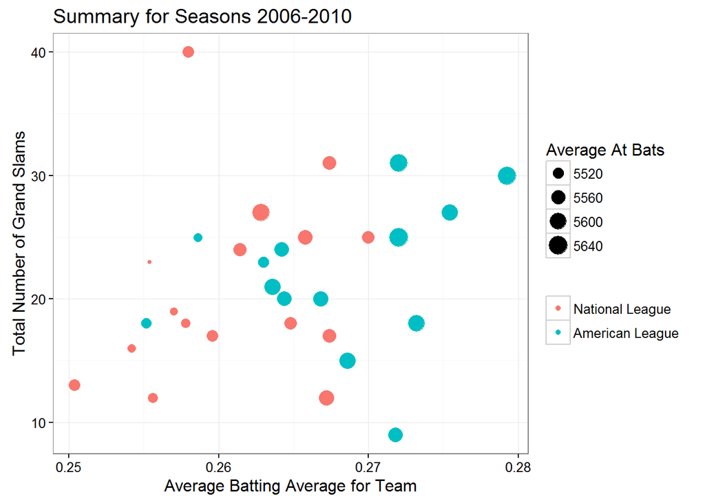

## Problem 4 (Data Input/Output)

The dataset we have contains a lot of data, but it does not contain all information we might want to know about each team. As an example, the location of each team’s stadium is not included in the original dataset. However, this data is available on Wikipedia:

https://en.wikipedia.org/wiki/Major_League_Baseball

The third section on the wikipedia page includes a table which has summary information for each of the teams. You are to write code which scrapes this dataset to make it available in `R`. Note: you do not need to perform any cleaning on the dataset after reading it into `R` (see next exercise). Your dataset should be in a dataframe, the first 6 rows of which are shown below:

```
         Division              Team               City
1 American League   American League    American League
2            East Baltimore Orioles      Baltimore, MD
3            East    Boston Red Sox         Boston, MA
4            East  New York Yankees  New York City, NY
5            East    Tampa Bay Rays St. Petersburg, FL
6            East Toronto Blue Jays        Toronto, ON
                      Stadium        Capacity
1             American League American League
2 Oriole Park at Camden Yards          45,971
3                 Fenway Park          37,949
4              Yankee Stadium          49,638
5             Tropicana Field          31,042
6               Rogers Centre          49,282
                                                                                                                            Coordinates
1                                                                                                                       American League
2  39°17'2″N 76°37'18″W / 39.28389°N 76.62167°W / 39.28389; -76.62167 (Baltimore Orioles)
3     42°20'47″N 71°5'51″W / 42.34639°N 71.09750°W / 42.34639; -71.09750 (Boston Red Sox)
4  40°49'45″N 73°55'35″W / 40.82917°N 73.92639°W / 40.82917; -73.92639 (New York Yankees)
5     27°46'6″N 82°39'12″W / 27.76833°N 82.65333°W / 27.76833; -82.65333 (Tampa Bay Rays)
6 43°38'29″N 79°23'21″W / 43.64139°N 79.38917°W / 43.64139; -79.38917 (Toronto Blue Jays)
          Founded          Joined  NA.
1 American League American League <NA>
2           1901*           1901* [21]
3            1901            1901 [22]
4           1901*           1901* [23]
5            1998            1998 [24]
6            1977            1977 [25]
```

## Problem 5 (Strings)

The data frame you constructed in Problem 4 is quite messy. It needs to be cleaned up in order to get useful information out of it. In particular, you should perform the following steps:

- Remove last column (which has title `NA`).
- There are two rows in the dataset which act like headers specifying the corresponding league of the team. These should be removed and turned into a variable specifying the `League` as in the original MLB dataset.
- The Capacity of the stadium should be turned into a numeric variable.
- The coordinates of the stadium are currently a long text string. This variable should be removed. Instead, it should be replaced with two numeric variables (`latitude` and `longitude`), which are constructed by pulling out the latitude and longitude from the text string (they are the numeric values in the string which are not in degrees and minutes).

Note: if you were unable to obtain the data from the website in the previous step, you can use the data from the course site entitled `Wiki Page final data.csv`.

The first 6 rows of your cleaned dataset should look like the following:

```
  Division              Team               City
1     East Baltimore Orioles      Baltimore, MD
2     East    Boston Red Sox         Boston, MA
3     East  New York Yankees  New York City, NY
4     East    Tampa Bay Rays St. Petersburg, FL
5     East Toronto Blue Jays        Toronto, ON
6  Central Chicago White Sox        Chicago, IL
                      Stadium Capacity Founded Joined League Latitude
1 Oriole Park at Camden Yards    45971   1901*  1901*     AL 39.28389
2                 Fenway Park    37949    1901   1901     AL 42.34639
3              Yankee Stadium    49638   1901*  1901*     AL 40.82917
4             Tropicana Field    31042    1998   1998     AL 27.76833
5               Rogers Centre    49282    1977   1977     AL 43.64139
6         U.S. Cellular Field    40615    1901   1901     AL 41.83000
  Longitude
1 -76.62167
2 -71.09750
3 -73.92639
4 -82.65333
5 -79.38917
6 -87.63389
```

## Problem 6 (Dynamic Graphics)

The Wikipedia page examined in Problem 4 contained a map of the stadiums across the US, color-coded by the league and division. However, this graphic did not have any interactive components. We would like to construct a graphic which is interactive. Specifically, it should have the following components:

- The locations of the stadiums plotted on a map of the continental US.
- The stadiums are color-coded by *division* and *league*.
- The names of the stadiums appear on the graphic also.
- The legend is interactive, clicking on an element subsets the data.

Note, this requires merging the data from the Wikipedia page after cleaning with the MLB data. If you were unable to clean the Wikipedia page, use the data on the course site entitled `Cleaned Wiki Page final data.csv`. There are a few things to be aware of when merging:

- At the time the MLB data was collected, the Houston Astros were part of the National League; they have since become part of the American League; so, the League from the Wikipedia data needs to be updated to place this team as the National League (to match when the data was collected).
- The Los Angeles Angels have an extended name on the Wikipedia data, retain the namefrom the MLB data.
- The Miami Marlins are recorded as the Florida Marlins in the MLB data, retain the name from the MLB data.

Your final graphic should emulate what is below:

http://bl.ocks.org/reyesem/raw/087c953e29094be3a3d8e17dba4570f1/

## Problem 7 (Simulation)

The *on base percentage (OBP)* for a player is an estimate of the probability the player will get on base when stepping up to bat. The `OBP` variable reported in the MLB data is the average of the on base percentage for all players on the team over the five seasons observed. Therefore, it is not a true representation of an *individual’s* performance. For example, for the Chicago Cubs, the OBP in the MLB dataset is 0.3316. However, individuals on the team will vary about that value. Suppose we are willing to make the following assumptions:

- Let $X_i$ be the OBP for the $i$-th individual on a team.
- $X_i \sim N(\mu, 0.06^2)$ where $\mu$ is the average OBP for the team.
- The players up to bat in an inning are randomly chosen from the team.
- Players only get “out” if they strike out.
- The inning continues until there are three outs.

Admittedly, these are unrealistic assumptions. However, under these assumptions, write a small simulation that examines the distribution of the number of batters the Cubs will send up in the inning will see before it ends. Your final histogram (over 10000 replications) should look like the following:

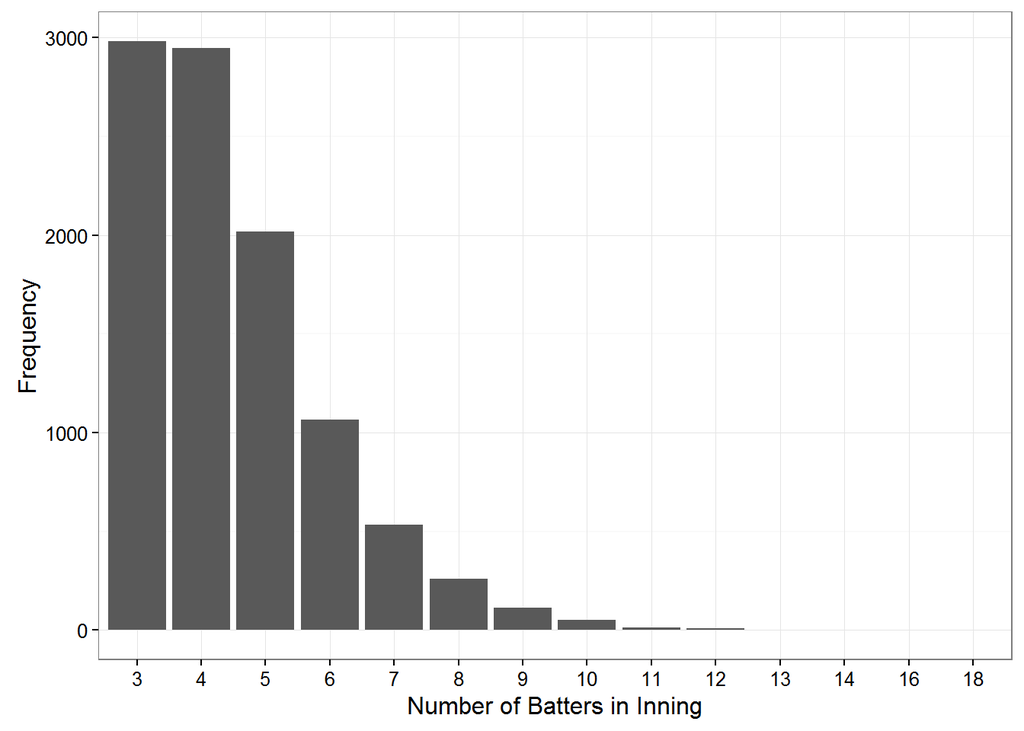

### Problem 8 (Randomization-Based Inference)

Suppose we want to compare the number of grand slams over the 5 seasons recorded for the American and National Leagues. A standard approach would be to construct a 95% confidence interval for $\mu_1 - \mu_2$ where $\mu_1$ is the average number of grand slams for an American League team and $\mu_2$ is the average number of grand slams for a National League team. We might do this using a t-interval, for example:
$$\bar{y}_1 - \bar{y}_2 \pm t_{df, 0.975} \sqrt{s_1^2/n_1 + s_2^2/n_2}$$

which is based on modeling the ratio
$$\frac{\left(\bar{y}_1 - \bar{y}_2\right) - \left(\mu_1 - \mu_2\right)}{\sqrt{s_1^2/n_1 + s_2^2/n_2}}$$

using a t-distribution. However, this model requires the assumption that each of the two populations follows a Normal distribution. This is a limiting assumption. Write a bootstrapping algorithm to compute a 95% confidence interval for the difference in the average number of grand slams achieved for the two leagues. Your interval should roughly equal:

```
     2.5%     97.5%
-4.125223  5.205357
```

## Problem 9 (Machine Learning)

We now turn to using the features of the MLB dataset to build a machine learning algorithm to predict the number of grand slams a team will have over 5 seasons. Write code which does the following:

- Uses **all** data for training, given the small size of the dataset.
- Use a conditional inference random forest model.
- Tune the `mtry` parameter over a grid of integers between 3 and 10 inclusive, using 5-fold cross-validation.
- Be sure to *not* consider the Team Name (as well as the Short Name) as a feature in the model.

The MSE for your model in the MLB dataset should be as follows:

```
[1] 29.325
```

## Problem 10 (Reproducible Research)

Write your solutions to the exam using R Markdown and submit your code and any relevant output as an HTML page. A couple of things regarding your solutions:

- Place all code in a code block that is echoed in the document.
- Place any supporting text, if needed, around the code.
- Denote each problem using a 2nd level header.
- If you attempted the interactive problem, you need not include the supporting files for making this graphic work in your submission.
- Be sure your name is on the document.